Hello there, gentle reader. Let me introduce myself. I am Michael Kilgore, a drive-in theater historian and author of several books on the subject. I have what they call "domain knowledge" or expertise about theaters and movies over the decades.

Anecdotally, it seems as though typical movie lengths have grown longer over the years. Matinee westerns in the 1940s could be only about an hour long, but today’s films sort of need to be around two hours or more to be taken seriously.

# First Questions

1. Are movies actually getting longer?
2. Does that answer vary by genre? That is, are comedies getting longer, rather than dramas?

Looking for data that could answer these questions, I was really happy to find RJ Ziarani’s “48K IMDB Movies With Datasets” (https://www.kaggle.com/datasets/rezaunderfit/48k-imdb-movies-data) on Kaggle. There are a few issues with the data, but there sure is a lot of it. As its name suggests, it includes over 48,000 IMDb records covering 1874 to 2021. Each record includes the movie’s release date, length, and up to three genres. (For example, the 2012 Jonah Hill film “21 Jump Street” (https://www.imdb.com/title/tt1232829/) is a Comedy, an Action movie, and a Crime movie.)

Perhaps more importantly, each record also has a rating, or score, based on a 1-10 scale. It also includes the number of IMDb users who submitted their review scores for that movie. Through my domain knowledge, I can tell you that these ratings are far from perfect. Reviewers are self-selected; each one chose to watch that movie, probably expecting that it would be worth their time. Despite that shortcoming, the inclusion of ratings opens the door to more questions about how “good” a movie is.

# Further questions after identifying data source

1. Are longer movies considered to be better movies?
2. Does that answer vary by genre? That is, are longer comedies, rather than dramas, considered to be better?

And one more set of questions that might be useful for anyone involved in creating new movies:

3. Is there a movie length that is correlated with optimal movie quality, based on score?
4. Is there a movie length that is correlated with optimal movie popularity, based on number of “voters”?

Do those answers vary by genre?

Now let’s get back to Ziarani’s data set. Its initial state is awkward to work with. Each of those 48,000+ records is a JSON statement in its own file, arranged in directories by year. Rather than build a Python program to span all of those subdirectories, I used Windows File Manager to find all .json files in the project, then moved them all into a single directory. That made it easier to write a Python program to cycle through them all to build a Pandas dataframe.

The next issue to grapple with was genre. If I were building a relational database, I’d include a table of genres and a linking table for which movies were associated with which genres. Instead, I needed a dataframe, so I added a column for each genre. When reading in each movie record, I would reset all genre columns to zero, parse the genres, then mark the matches by changing their values to one. After a little digging online, I found the 19 genres that IMDb employs and built my list of genres accordingly.

I created smaller sets of JSON records to test my input program as I went. That’s how I learned to pay attention to another field, “Type”. It turned out that the huge majority of Ziarani’s records were classified as “Movie”, but a significant number were something else, such as “Short” or “TV Show”. I used the input program to pre-filter those non-movies out of the dataframe I was building. Similarly, I discovered that some records were lacking genre, release date, rating, or running time. For general data cleaning, I changed my input program to also screen out these outliers.

The following omits one step for your reading convenience. After I compiled the dataframe once, in my first pass of exploratory data analysis, I noticed that some so-called records that IMDb identified as "Movie" had lengths as low as 1 minute. Using domain knowledge, I would not categorize such short subjects that way. I established a minimum length using the matinee westerns, which could be as short as 55 minutes (for later, trimmed prints), and added that step in my pre-processing data cleaning. I started over with the code below.

```python
from pathlib import Path
import os
import json
import pandas as pd
import textwrap
import re

# Title truncation trick from TutorPython.com
def truncate(s, limit):
    truncated = textwrap.shorten(s, width=limit, placeholder="...")
    return truncated

pathBase = 'C:/IMDB/'
recordList = []
fileList = []
fileList = os.listdir(pathBase)
knownGenre = ['Action', 'Adventure', 'Animation', 'Biography', 'Comedy',
              'Crime', 'Drama', 'Documentary', 'Family', 'Fantasy',
              'History', 'Horror', 'Musical', 'Mystery', 'Romance',
              'Sci-Fi', 'Thriller', 'War', 'Western']
progressGauge = 0

# Notes say that building a list of lists, then converting to pandas dataframe
#   is much faster than growing the dataframe record by record
for i in fileList:
    if not (i.endswith('.json')):
         # skip everything except json files
         continue

    # Every genre is missing (zero) by default
    includedGenres = [0,0,0,0,0,0,0,0,0,0,0,0,0,0,0,0,0,0,0]

    # Mechanism to show it's working, otherwise would output nothing for several minutes
    progressGauge = progressGauge + 1
    if progressGauge % 5000 == 0:
        print(progressGauge)

    pathFile = i
    fullName = pathBase + pathFile
    p = Path(fullName)

    f = p.open()
    data = json.load(f)
    localList = []

    #   Here is the primary Data Cleaning step in this project.
    # Working with smaller test sets of JSON files, I found that
    # some of them were missing crucial information. Rather than
    # dumping these records after processing, I choose to simply
    # skip over them while creating the original dataframe.
    strType = data['@type']
    if "Movie" != strType:
        #not a movie, so skip this record
        f.close()
        continue
    if 'genre' not in data:
        #skip this record
        f.close()
        continue
    if 'datePublished' not in data:
        #skip this record
        f.close()
        continue
    if 'aggregateRating' not in data:
        #skip this record
        f.close()
        continue
    if 'duration' not in data:
        #skip this record
        f.close()
        continue

    strURL = data['url']
    strName = data['name']

    # Since IMDb entries can have multiple genres, check each one
    listGenre = data['genre']
    for genre in knownGenre:
        if genre in listGenre:
            includedGenres[knownGenre.index(genre)] = 1

    strDate = data['datePublished']
    strYear = strDate[:4]
    intYear = int(strYear)
    listRating = data['aggregateRating']
    intVoters = int(listRating['ratingCount'])
    floatScore = float(listRating['ratingValue'])

    # Translate duration to minutes, no matter how it's formatted
    strTime = data['duration']
    if "H" in strTime:
        strHours = strTime[2]
        intMinutes = int(strHours) * 60
    else:
        intMinutes = 0
    if "M" in strTime:
        strMinutes = strTime[-3:]
        strNumMinutes = ''.join(c for c in strMinutes if c.isdigit())
        intMinutes = intMinutes + int(strNumMinutes)

    #   The first time I did this, I discovered some IMDb 'Movies'
    # were as short as 1 minute. I could dump the records after this
    # process, but why not add that to the rest of the Data Cleaning
    # steps shown above?
    #   As explained in accompanying notes, some matinee westerns
    # could be as short as an hour, give or take five minutes.
    # So that's the figure I'll use as the arbitrary cutoff value.
    if intMinutes < 55:
        continue

#    localList.append(strType) # They should all be 'Movie'
    localList.append(truncate(strName, 25))
    localList.append(intYear)
    localList.append(floatScore)
    localList.append(intVoters)
    localList.append(strTime)
    localList.append(intMinutes)
    # I could have used includedGenres.index each time, but +1 addition is probably faster
    i = 0
    for genre in knownGenre:
        localList.append(includedGenres[i])
        i = i + 1

    recordList.append(localList)

    f.close()

recordDF = pd.DataFrame(recordList)
columnNames = ['Name', 'Year', 'Score', 'Voters', 'Time', 'Minutes']
columnNames = columnNames + knownGenre
recordDF.columns = columnNames

# Save this original dataframe to a file for other users,
# so they don't have to repeat this data assembling and cleaning step
recordDF.to_csv('C:/IMDB/IMDb48kDF.csv', index=False)

# Quick check to make sure the numeric values look right,
# and an indication that we're done writing the CSV file.
meanList = recordDF.mean(numeric_only=True)
print(meanList)
```

```
5000
10000
15000
20000
25000
30000
35000
40000
45000
Year            1993.110972
Score              6.290732
Voters         18311.175325
Minutes          100.252892
Action             0.145629
Adventure          0.100239
Animation          0.026590
Biography          0.053156
Comedy             0.324941
Crime              0.148040
Drama              0.546213
Documentary        0.084637
Family             0.062707
Fantasy            0.070983
History            0.045437
Horror             0.110926
Musical            0.027842
Mystery            0.082365
Romance            0.201312
Sci-Fi             0.073093
Thriller           0.204627
War                0.046387
Western            0.025523
dtype: float64
```

This column of means is just the beginning of my exploratory data analysis. It shows a few bits of trivia not directly related to my questions. The average IMDb movie score is about 6.29, well above the scale's midpoint of 5.5. That ties in with my domain knowledge note about self-selecting reviewers who watch movies they believe they will enjoy. The most common genre by far is Drama (54.6% of movies), followed by Comedy and Thriller. The least common genre is Western (2.55%), followed closely by Animation and Musical.

The first pre-process data cleaning brought the number of clean records to 45,112. Adding the filter for running times of less than 55 minutes removed another 1,975 records, about 4.38% of the otherwise clean set.

```python
print(recordDF.describe(include = 'all'))
print(recordDF.columns)
print("Dataframe is", type(recordDF))
print("Number of records is", recordDF.shape[0])
print("")
print("   Year summary")
print(recordDF.Year.describe())
print("")
print("   Voters summary")
print(recordDF.Voters.describe().apply("{0:.2f}".format))
print("")
print("   Score summary")
print(recordDF.Score.describe())
print("")
print("   Minutes summary")
print(recordDF.Minutes.describe())
```

```
                            Name          Year         Score        Voters  \
count                      43137  43137.000000  43137.000000  4.313700e+04
unique                     40786           NaN           NaN           NaN
top     Perry Mason: The Case...           NaN           NaN           NaN
freq                          24           NaN           NaN           NaN
mean                         NaN   1993.110972      6.290732  1.831118e+04
std                          NaN     23.042160      1.099771  7.544059e+04
min                          NaN   1906.000000      1.100000  5.000000e+00
25%                          NaN   1979.000000      5.700000  5.840000e+02
50%                          NaN   2002.000000      6.400000  1.655000e+03
75%                          NaN   2011.000000      7.100000  6.139000e+03
max                          NaN   2021.000000      9.300000  2.324543e+06

           Time       Minutes        Action     Adventure     Animation  \
count     43137  43137.000000  43137.000000  43137.000000  43137.000000
unique      222           NaN           NaN           NaN           NaN
top     PT1H30M           NaN           NaN           NaN           NaN
freq       2526           NaN           NaN           NaN           NaN
mean        NaN    100.252892      0.145629      0.100239      0.026590
std         NaN     21.627006      0.352738      0.300322      0.160883
min         NaN     55.000000      0.000000      0.000000      0.000000
25%         NaN     88.000000      0.000000      0.000000      0.000000
50%         NaN     96.000000      0.000000      0.000000      0.000000
75%         NaN    108.000000      0.000000      0.000000      0.000000
max         NaN    566.000000      1.000000      1.000000      1.000000

           Biography  ...       Fantasy       History        Horror  \
count   43137.000000  ...  43137.000000  43137.000000  43137.000000
unique           NaN  ...           NaN           NaN           NaN
top              NaN  ...           NaN           NaN           NaN
freq             NaN  ...           NaN           NaN           NaN
mean        0.053156  ...      0.070983      0.045437      0.110926
std         0.224348  ...      0.256800      0.208262      0.314044
min         0.000000  ...      0.000000      0.000000      0.000000
25%         0.000000  ...      0.000000      0.000000      0.000000
50%         0.000000  ...      0.000000      0.000000      0.000000
75%         0.000000  ...      0.000000      0.000000      0.000000
max         1.000000  ...      1.000000      1.000000      1.000000

             Musical       Mystery       Romance        Sci-Fi      Thriller  \
```

[output cut: 62 more lines]

```
50%          6.400000
75%          7.100000
max          9.300000
Name: Score, dtype: float64

   Minutes summary
count    43137.000000
mean       100.252892
std         21.627006
min         55.000000
25%         88.000000
50%         96.000000
75%        108.000000
max        566.000000
Name: Minutes, dtype: float64
```

This round of exploratory data analysis shows that the records seem to be okay, with no NaNs fouling the summaries. The data cleaning process eliminated all movies before 1906. They were probably too short or were missing vital information. The minimum number of Voters is 5; I suspect IMDb doesn't compile a movie's score until it gets at least five user ratings. The lowest score is 1.1 and the highest is 9.3. Considering those are averages of at least five user scores each, those are in line with expectations. Minimum minutes is 55, as guaranteed by that extra step of data cleaning. Maximum minutes is 566, over nine hours. Since the questions are about average movie lengths, I'm inclined to retain the long outliers, but let's see how that affects our charts.

I'll start by looking at all of the data.

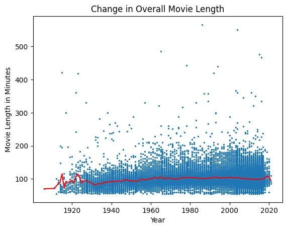

```python
from pylab import *
import matplotlib.pyplot as plt

yearLength = recordDF.sort_values(by="Year")
yearLength = yearLength.groupby(by="Year", as_index = False)
yearMins = yearLength.Minutes.mean()

figure()
plot(yearMins.Year, yearMins.Minutes, 'r')
xlabel('Year')
ylabel('Movie Length in Minutes')
title('Change in Overall Movie Length')
plt.scatter(recordDF.Year, recordDF.Minutes, s = 2)
plt.show()
```

Some of those outliers look pretty far out. The average length of all movies looks fairly consistent over the years, but let's examine the trend more closely without the scatterplot.

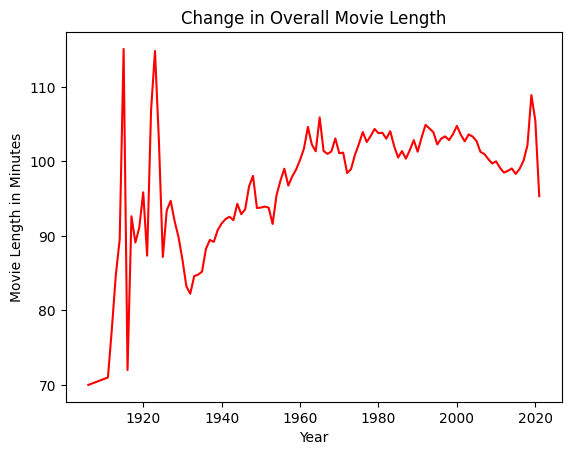

```python
figure()
plot(yearMins.Year, yearMins.Minutes, 'r')
xlabel('Year')
ylabel('Movie Length in Minutes')
title('Change in Overall Movie Length')
show()
```

That answers the very first question, albeit ambiguously. Depending on the chosen beginning and end points, one could easily say that on average movies are getting longer, or that they are getting shorter.

Now to the second question. Let's continue the exploratory data analysis by checking the genres in alphabetical order, starting with Action.

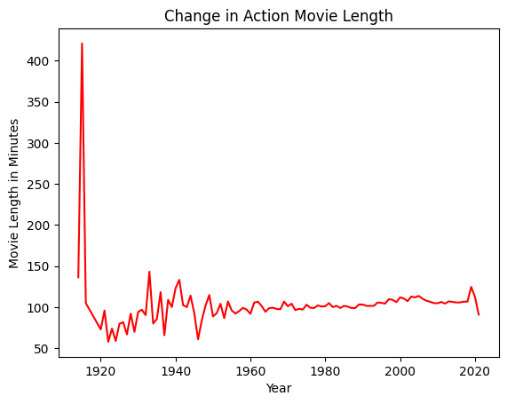

```python
actionDF = recordDF[recordDF['Action'] == 1]
actionLength = actionDF.groupby(by="Year", as_index = False)
actionAvg = actionLength.Minutes.mean()
figure()
plot(actionAvg.Year, actionAvg.Minutes, 'r')
xlabel('Year')
ylabel('Movie Length in Minutes')
title('Change in Action Movie Length')
show()
```

There's an outlier that's so large that it's throwing off the scale for the entire graph. What is it?

```python
print("Long movie is:", actionDF[(actionDF['Minutes']>200) & (actionDF['Year']<1930)].Name)
```

```
Long movie is: 31    Les vampires
Name: Name, dtype: object
```

Aha! This was "Les Vampires" (https://www.imdb.com/title/tt0006206/), a 1915 French 10-part serial that was stitched together into a really long movie. I'll clean the data once more by removing that record, then I'll start over with the genres.

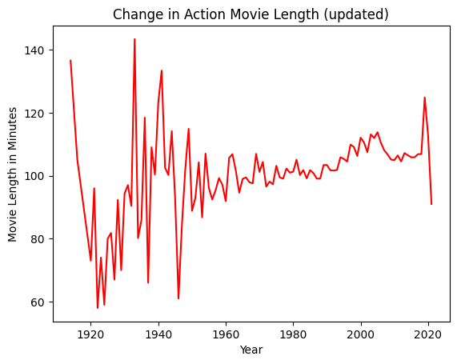

```python
recordDF = recordDF.drop(recordDF[recordDF['Name'] == "Les vampires"].index)
actionDF = recordDF[recordDF['Action'] == 1]
actionLength = actionDF.groupby(by="Year", as_index = False)
actionAvg = actionLength.Minutes.mean()
figure()
plot(actionAvg.Year, actionAvg.Minutes, 'r')
xlabel('Year')
ylabel('Movie Length in Minutes')
title('Change in Action Movie Length (updated)')
show()
```

Much better, but the trends are different than movies as a whole. Once the average settled in the late 1940s, the average length of an Action movie showed an upward trend until about 2005.

Next on the genre list is Adventure:

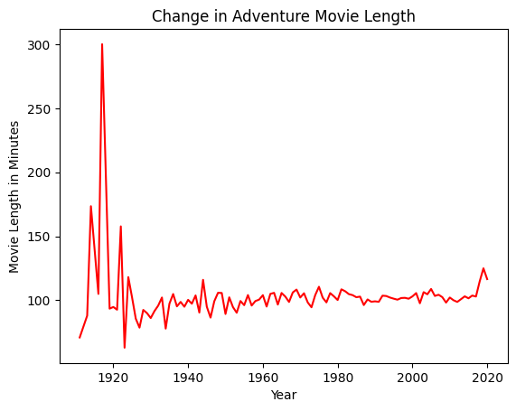

```python
advDF = recordDF[recordDF['Adventure'] == 1]
advLength = advDF.groupby(by="Year", as_index = False)
advAvg = advLength.Minutes.mean()
figure()
plot(advAvg.Year, advAvg.Minutes, 'r')
xlabel('Year')
ylabel('Movie Length in Minutes')
title('Change in Adventure Movie Length')
show()
```

Good thing we're doing this exploratory data analysis. There's another outlier distorting the chart scale. Let's see what movie this one is.

```python
print("Long movie is:", advDF[(advDF['Minutes']>200) & (advDF['Year']<1930)].Name)
```

```
Long movie is: 42                    Judex
125    The Adventures of...
Name: Name, dtype: object
```

Aha! The outlier is "Judex" (https://www.imdb.com/title/tt0006886/), a 1916 French 12-part serial that was also stitched together into a really long movie. I'll clean the data once more by removing that record, then I'll rebuild the Adventure chart.

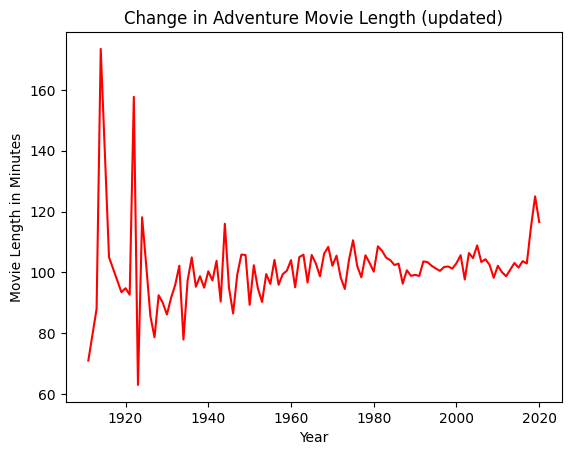

```python
recordDF = recordDF.drop(recordDF[recordDF['Name'] == "Judex"].index)
advDF = recordDF[recordDF['Adventure'] == 1]
advLength = advDF.groupby(by="Year", as_index = False)
advAvg = advLength.Minutes.mean()
figure()
plot(advAvg.Year, advAvg.Minutes, 'r')
xlabel('Year')
ylabel('Movie Length in Minutes')
title('Change in Adventure Movie Length (updated)')
show()
```

There are still some pre-1930 outliers, but they're having less affect on the chart, which shows a much shallower upward trend from 1940 to 2015.

Now let's see whether Animation has any distorting outliers.

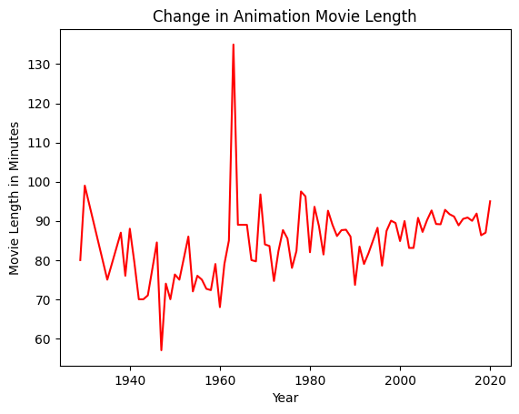

```python
aniDF = recordDF[recordDF['Animation'] == 1]
aniLength = aniDF.groupby(by="Year", as_index = False)
aniAvg = aniLength.Minutes.mean()
figure()
plot(aniAvg.Year, aniAvg.Minutes, 'r')
xlabel('Year')
ylabel('Movie Length in Minutes')
title('Change in Animation Movie Length')
show()
```

There's another one, this time from the early 1960s. Let's explore whether we want to keep it.

```python
print("Long movie is:", aniDF[(aniDF['Minutes']>120) & (aniDF['Year']>1960) & (aniDF['Year']<1968)].Name)
```

```
Long movie is: 5477    The Wonderful World of...
Name: Name, dtype: object
```

That one's unusual. It's "The Wonderful World of the Brothers Grimm" (https://www.imdb.com/title/tt0056700/), a 135-minute 1962 movie that combined a few animated sequences with mostly live action. As I type in 2024, IMDb no longer tags it as Animation. It's not a completely strange running time for live action, so I'll leave the movie in the main dataframe but remove it from the Animation graph.

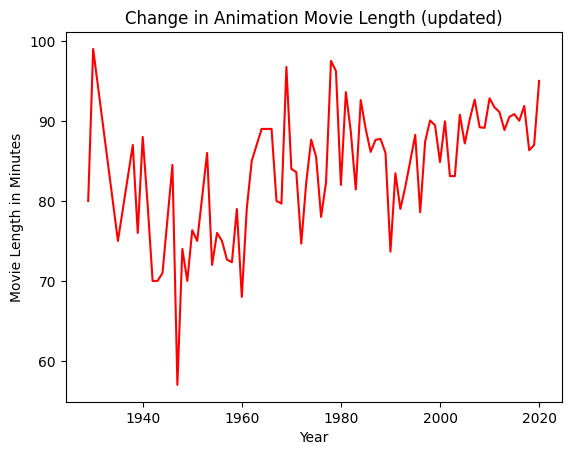

```python
aniDF = aniDF.drop(aniDF[aniDF['Name'] == "The Wonderful World of..."].index)
aniLength = aniDF.groupby(by="Year", as_index = False)
aniAvg = aniLength.Minutes.mean()
figure()
plot(aniAvg.Year, aniAvg.Minutes, 'r')
xlabel('Year')
ylabel('Movie Length in Minutes')
title('Change in Animation Movie Length (updated)')
show()
```

That chart presents a much clearer upward trend from the late 1940s to 2020.

Next up is Biography:

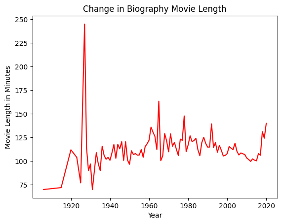

```python
bioDF = recordDF[recordDF['Biography'] == 1]
bioLength = bioDF.groupby(by="Year", as_index = False)
bioAvg = bioLength.Minutes.mean()
figure()
plot(bioAvg.Year, bioAvg.Minutes, 'r')
xlabel('Year')
ylabel('Movie Length in Minutes')
title('Change in Biography Movie Length')
show()
```

```python
print("Long movie is:", bioDF[(bioDF['Minutes']>180) & (bioDF['Year']<1930)].Name)
```

```
Long movie is: 302    Napoléon vu par Abel...
Name: Name, dtype: object
```

This time the outlier is the 1927 epic "Napoleon" (https://www.imdb.com/title/tt0018192/). It's fairly popular with IMDb users, who rate it highly, so I think it's better to keep this one. The Biography chart generally shows running times peaking around 1960 then slowly declining until a recent uptick.

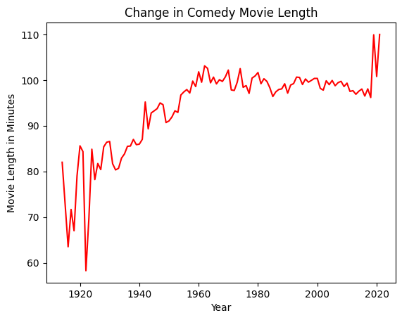

```python
comDF = recordDF[recordDF['Comedy'] == 1]
comLength = comDF.groupby(by="Year", as_index = False)
comAvg = comLength.Minutes.mean()
figure()
plot(comAvg.Year, comAvg.Minutes, 'r')
xlabel('Year')
ylabel('Movie Length in Minutes')
title('Change in Comedy Movie Length')
show()
```

At last, a genre without distorting outliers! I was surprised to see the average Comedy length peak in the early 1960s, then decline slightly until a recent spurt upwards.

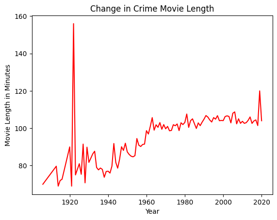

```python
crimeDF = recordDF[recordDF['Crime'] == 1]
crimeLength = crimeDF.groupby(by="Year", as_index = False)
crimeAvg = crimeLength.Minutes.mean()
figure()
plot(crimeAvg.Year, crimeAvg.Minutes, 'r')
xlabel('Year')
ylabel('Movie Length in Minutes')
title('Change in Crime Movie Length')
show()
```

```python
print("Long movie is:", crimeDF[(crimeDF['Minutes']>120) & (crimeDF['Year']<1930)].Name)
```

```
Long movie is: 130    Dr. Mabuse, der Spieler
Name: Name, dtype: object
```

The outlier in this chart is "Dr. Mabuse, der Spieler" (https://www.imdb.com/title/tt0013086/), a 4-hour 1922 German film directed by the legendary Fritz Lang. It has more Voters than "Napoleon" and a similar score, so I guess I need to keep this outlier too. Despite its presence, it's easy to see that Crime movie length rose from 1940 to about 1990 before levelling off.

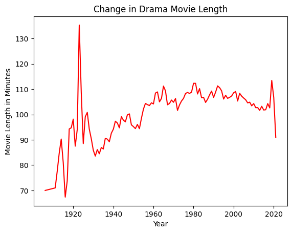

```python
dramaDF = recordDF[recordDF['Drama'] == 1]
dramaLength = dramaDF.groupby(by="Year", as_index = False)
dramaAvg = dramaLength.Minutes.mean()
figure()
plot(dramaAvg.Year, dramaAvg.Minutes, 'r')
xlabel('Year')
ylabel('Movie Length in Minutes')
title('Change in Drama Movie Length')
show()
```

Since a majority of movies in the dataframe are Drama, it's no surprise that the Drama chart parallels the overall movie length chart.

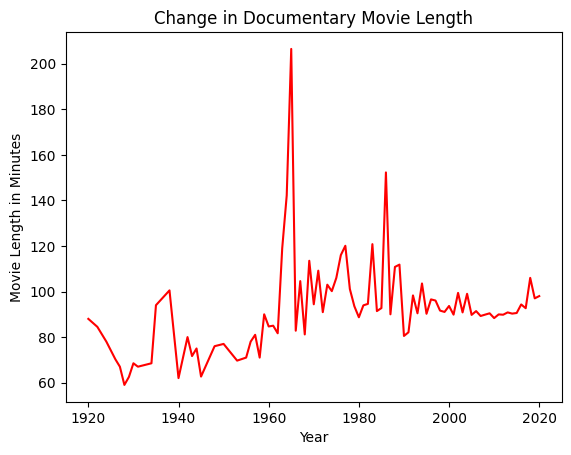

```python
docDF = recordDF[recordDF['Documentary'] == 1]
docLength = docDF.groupby(by="Year", as_index = False)
docAvg = docLength.Minutes.mean()
figure()
plot(docAvg.Year, docAvg.Minutes, 'r')
xlabel('Year')
ylabel('Movie Length in Minutes')
title('Change in Documentary Movie Length')
show()
```

```python
print("Long movie is:", docDF[(docDF['Minutes']>180) & (docDF['Year']<1966)].Name)
```

```
Long movie is: 19671    Empire
Name: Name, dtype: object
```

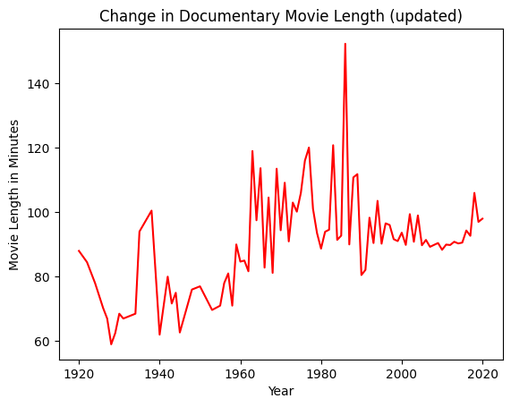

```python
recordDF = recordDF.drop(recordDF[recordDF['Name'] == "Sleep"].index)
recordDF = recordDF.drop(recordDF[recordDF['Name'] == "Empire"].index)
docDF = recordDF[recordDF['Documentary'] == 1]
docLength = docDF.groupby(by="Year", as_index = False)
docAvg = docLength.Minutes.mean()
figure()
plot(docAvg.Year, docAvg.Minutes, 'r')
xlabel('Year')
ylabel('Movie Length in Minutes')
title('Change in Documentary Movie Length (updated)')
show()
```

```python
print("Long movie is:", docDF[(docDF['Minutes']>240) & (docDF['Year']>1982) & (docDF['Year']<1990)].Name)
```

```
Long movie is: 12220             Shoah
13227    Hôtel Terminus
13694        Near Death
17940      Tôkyô saiban
19301             Diary
Name: Name, dtype: object
```

There are several 1980s Documentary movies that might be considered outliers. The longest among them is "Shoah" (https://www.imdb.com/title/tt0090015/), a very highly regarded 9-hour remembrance of the Holocaust. Looking them over one by one, I'd say they all deserve to stay. Perhaps Documentary movie lengths are just more prone to variation, in that there are fewer of them and they have a wider range of running times.

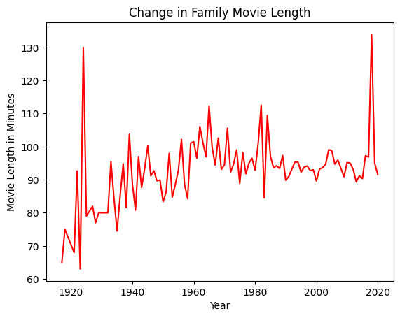

```python
famDF = recordDF[recordDF['Family'] == 1]
famLength = famDF.groupby(by="Year", as_index = False)
famAvg = famLength.Minutes.mean()
figure()
plot(famAvg.Year, famAvg.Minutes, 'r')
xlabel('Year')
ylabel('Movie Length in Minutes')
title('Change in Family Movie Length')
show()
```

```python
print("Early outlier is:", famDF[(famDF['Minutes']>120) & (famDF['Year']<1930)].Name)
print("Recent outlier is:", famDF[(famDF['Minutes']>160) & (famDF['Year']>2015)].Name)
```

```
Early outlier is: 141             Robin Hood
189    The Thief of Bagdad
Name: Name, dtype: object
Recent outlier is: 42125    Natsamrat
Name: Name, dtype: object
```

The early outliers are a couple of classic Douglas Fairbanks silent adventures: "Robin Hood" (https://www.imdb.com/title/tt0013556/), 1922, and "The Thief of Bagdad" (https://www.imdb.com/title/tt0015400/), 1924. The recent outlier is the 2016 Indian film "Natsamrat," also very highly regarded. I'll keep them all.

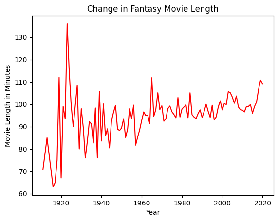

```python
fanDF = recordDF[recordDF['Fantasy'] == 1]
fanLength = fanDF.groupby(by="Year", as_index = False)
fanAvg = fanLength.Minutes.mean()
figure()
plot(fanAvg.Year, fanAvg.Minutes, 'r')
xlabel('Year')
ylabel('Movie Length in Minutes')
title('Change in Fantasy Movie Length')
show()
```

I was expecting a much stronger trend upward, but the slope from 1965 to 2015 looks almost flat.

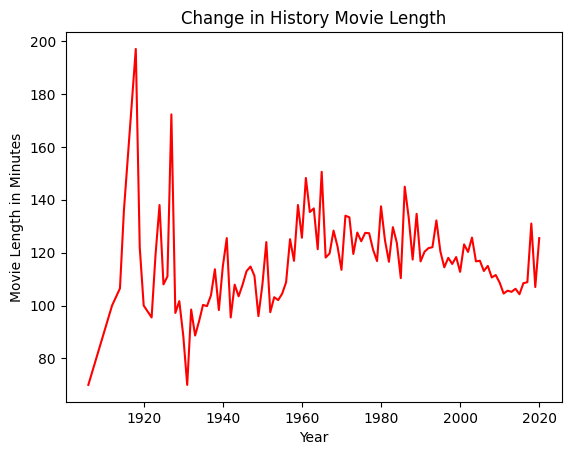

```python
hisDF = recordDF[recordDF['History'] == 1]
hisLength = hisDF.groupby(by="Year", as_index = False)
hisAvg = hisLength.Minutes.mean()
figure()
plot(hisAvg.Year, hisAvg.Minutes, 'r')
xlabel('Year')
ylabel('Movie Length in Minutes')
title('Change in History Movie Length')
show()
```

A clear downward trend from the early 1960s to 2015. Then again, History films are longer than most genres.

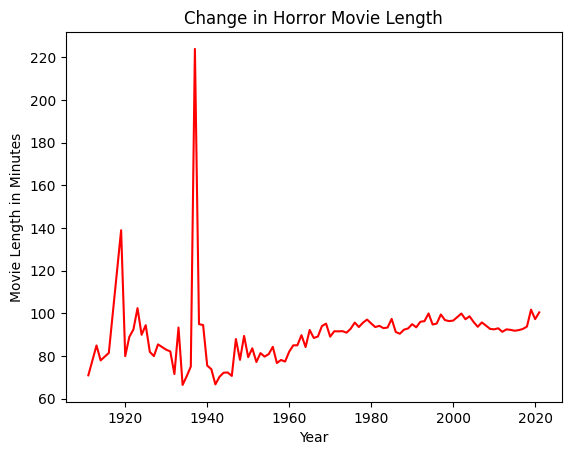

```python
horDF = recordDF[recordDF['Horror'] == 1]
horLength = horDF.groupby(by="Year", as_index = False)
horAvg = horLength.Minutes.mean()
figure()
plot(horAvg.Year, horAvg.Minutes, 'r')
xlabel('Year')
ylabel('Movie Length in Minutes')
title('Change in Horror Movie Length')
show()
```

```python
print("Outlier is:", horDF[(horDF['Minutes']>210) & (horDF['Year']<1940)].Name)
```

```
Outlier is: 818     The Whispering Shadow
1289          SOS Coast Guard
1539       The Phantom Creeps
Name: Name, dtype: object
```

"The Whispering Shadow" (https://www.imdb.com/title/tt0024768/), "SOS Coast Guard" (https://www.imdb.com/title/tt0029508/), and one of my favorites, "The Phantom Creeps" (https://www.imdb.com/title/tt0031796/) were all American serials that IMDb included as movies using their combined episodes' running times. There may be others, but these are the longest. They don't really belong in this movie dataframe.

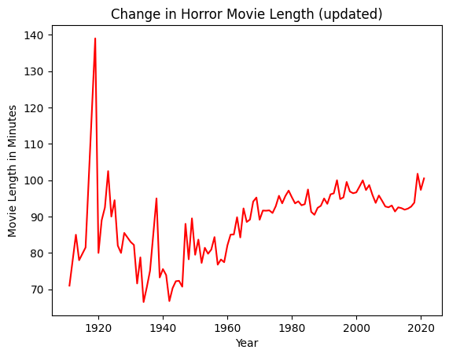

```python
recordDF = recordDF.drop(recordDF[recordDF['Name'] == "The Whispering Shadow"].index)
recordDF = recordDF.drop(recordDF[recordDF['Name'] == "SOS Coast Guard"].index)
recordDF = recordDF.drop(recordDF[recordDF['Name'] == "The Phantom Creeps"].index)
horDF = recordDF[recordDF['Horror'] == 1]
horLength = horDF.groupby(by="Year", as_index = False)
horAvg = horLength.Minutes.mean()
figure()
plot(horAvg.Year, horAvg.Minutes, 'r')
xlabel('Year')
ylabel('Movie Length in Minutes')
title('Change in Horror Movie Length (updated)')
show()
```

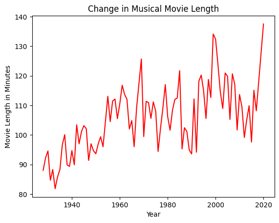

```python
musDF = recordDF[recordDF['Musical'] == 1]
musLength = musDF.groupby(by="Year", as_index = False)
musAvg = musLength.Minutes.mean()
figure()
plot(musAvg.Year, musAvg.Minutes, 'r')
xlabel('Year')
ylabel('Movie Length in Minutes')
title('Change in Musical Movie Length')
show()
```

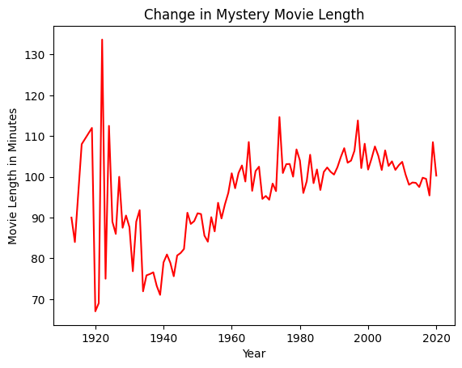

```python
mysDF = recordDF[recordDF['Mystery'] == 1]
mysLength = mysDF.groupby(by="Year", as_index = False)
mysAvg = mysLength.Minutes.mean()
figure()
plot(mysAvg.Year, mysAvg.Minutes, 'r')
xlabel('Year')
ylabel('Movie Length in Minutes')
title('Change in Mystery Movie Length')
show()
```

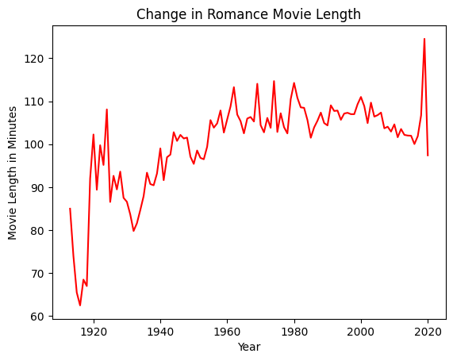

```python
romDF = recordDF[recordDF['Romance'] == 1]
romLength = romDF.groupby(by="Year", as_index = False)
romAvg = romLength.Minutes.mean()
figure()
plot(romAvg.Year, romAvg.Minutes, 'r')
xlabel('Year')
ylabel('Movie Length in Minutes')
title('Change in Romance Movie Length')
show()
```

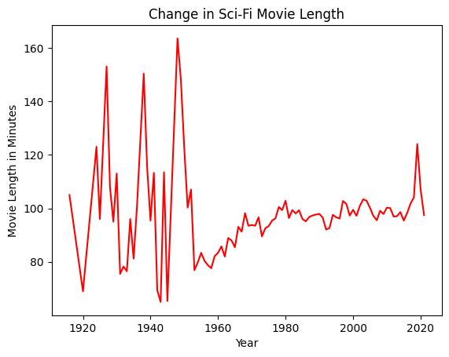

```python
sciDF = recordDF[recordDF['Sci-Fi'] == 1]
sciLength = sciDF.groupby(by="Year", as_index = False)
sciAvg = sciLength.Minutes.mean()
figure()
plot(sciAvg.Year, sciAvg.Minutes, 'r')
xlabel('Year')
ylabel('Movie Length in Minutes')
title('Change in Sci-Fi Movie Length')
show()
```

```python
print("Outliers are:", sciDF[(sciDF['Minutes']>140) & (sciDF['Year']<1960)].Name)
```

```
Outliers are: 259                    Metropolis
1104                 Flash Gordon
1374    Flash Gordon's Trip to...
1613                  Buck Rogers
1642     Flash Gordon Conquers...
1734     Adventures of Captain...
2144              Captain America
2791                     Superman
2830             Batman and Robin
2973        Atom Man vs. Superman
3164     Captain Video: Master...
3442      Radar Men from the Moon
3492            Zombies of the...
Name: Name, dtype: object
```

Except for the 1927 Fritz Lang masterpiece "Metropolis," (https://www.imdb.com/title/tt0017136/), all of these outliers are multipart serials that IMDb list with their combined running times. Let's remove the serials from the dataframe.

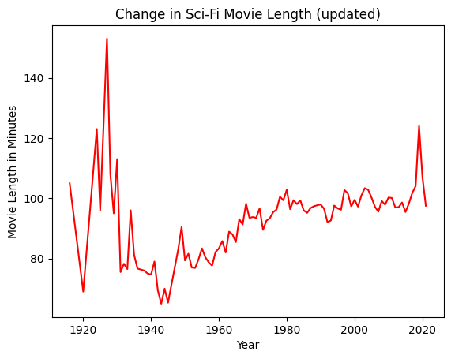

```python
# only delete the Flash Gordon serial, not the 1980 movie
oldFlashIndex = recordDF[(recordDF['Name'] == "Flash Gordon") & (recordDF['Year'] < 1950)].index
recordDF = recordDF.drop(oldFlashIndex)

recordDF = recordDF.drop(recordDF[recordDF['Name'] == "Flash Gordon's Trip to..."].index)
recordDF = recordDF.drop(recordDF[recordDF['Name'] == "Buck Rogers"].index)
recordDF = recordDF.drop(recordDF[recordDF['Name'] == "Flash Gordon Conquers..."].index)
recordDF = recordDF.drop(recordDF[recordDF['Name'] == "Adventures of Captain..."].index)

# only delete the Captain America serial, not either movie
oldCapIndex = recordDF[(recordDF['Name'] == "Captain America") & (recordDF['Year'] < 1950)].index
recordDF = recordDF.drop(oldCapIndex)

# only delete the Superman serial, not the 1978 movie
oldSupIndex = recordDF[(recordDF['Name'] == "Superman") & (recordDF['Year'] < 1950)].index
recordDF = recordDF.drop(oldSupIndex)

# IMDb lists the 1997 movie as "Batman & Robin" with the ampersand, so this is safe
recordDF = recordDF.drop(recordDF[recordDF['Name'] == "Batman and Robin"].index)
recordDF = recordDF.drop(recordDF[recordDF['Name'] == "Atom Man vs. Superman"].index)
recordDF = recordDF.drop(recordDF[recordDF['Name'] == "Captain Video: Master..."].index)
recordDF = recordDF.drop(recordDF[recordDF['Name'] == "Radar Men from the Moon"].index)
recordDF = recordDF.drop(recordDF[recordDF['Name'] == "Zombies of the..."].index)

sciDF = recordDF[recordDF['Sci-Fi'] == 1]
sciLength = sciDF.groupby(by="Year", as_index = False)
sciAvg = sciLength.Minutes.mean()
figure()
plot(sciAvg.Year, sciAvg.Minutes, 'r')
xlabel('Year')
ylabel('Movie Length in Minutes')
title('Change in Sci-Fi Movie Length (updated)')
show()
```

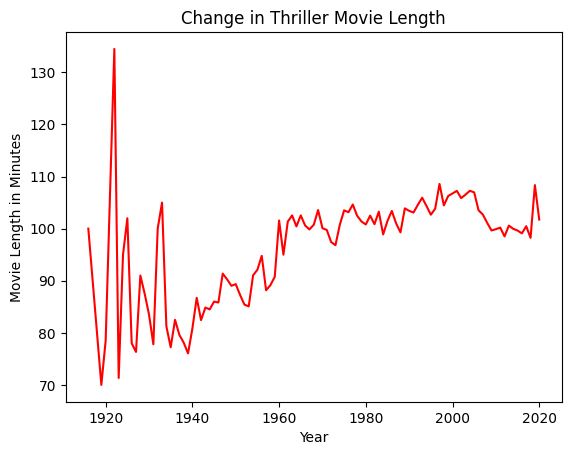

```python
thrDF = recordDF[recordDF['Thriller'] == 1]
thrLength = thrDF.groupby(by="Year", as_index = False)
thrAvg = thrLength.Minutes.mean()
figure()
plot(thrAvg.Year, thrAvg.Minutes, 'r')
xlabel('Year')
ylabel('Movie Length in Minutes')
title('Change in Thriller Movie Length')
show()
```

```python
print("Outliers are:", thrDF[(thrDF['Minutes']>140) & (thrDF['Year']<1930)].Name)
```

```
Outliers are: 130    Dr. Mabuse, der Spieler
Name: Name, dtype: object
```

The outlier is "Dr. Mabuse" again, stretching another genre chart.

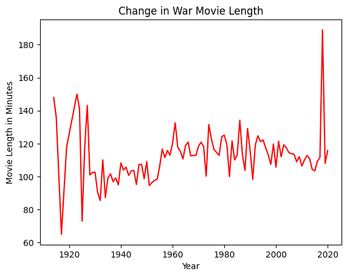

```python
warDF = recordDF[recordDF['War'] == 1]
warLength = warDF.groupby(by="Year", as_index = False)
warAvg = warLength.Minutes.mean()
figure()
plot(warAvg.Year, warAvg.Minutes, 'r')
xlabel('Year')
ylabel('Movie Length in Minutes')
title('Change in War Movie Length')
show()
```

```python
print("Outliers are:", warDF[(warDF['Minutes']>180) & (warDF['Year']>2013)].Name)
```

```
Outliers are: 42124    Werk ohne Autor
Name: Name, dtype: object
```

This is another weird outlier. "Never Look Away," which had the original title "Werk ohne Autor" (https://www.imdb.com/title/tt5311542/) is just 189 minutes long. Maybe there weren't any other War movies in the dataframe from 2018. (Also, IMDb no longer lists it as a War movie.)

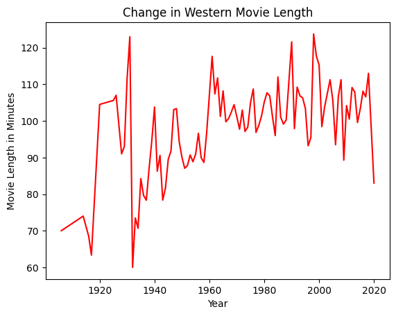

```python
westDF = recordDF[recordDF['Western'] == 1]
westLength = westDF.groupby(by="Year", as_index = False)
westAvg = westLength.Minutes.mean()
figure()
plot(westAvg.Year, westAvg.Minutes, 'r')
xlabel('Year')
ylabel('Movie Length in Minutes')
title('Change in Western Movie Length')
show()
```

The 1930s show the influence of those short matinee westerns, but otherwise, there's quite a bit of variance between years.